# Ghosts

Paulo Sigrist

11/14/2016

# Kaggle - Ghosts Competition

First, load data:

```r
# Load data
train <- read.csv('train.csv', stringsAsFactors = F)
test  <- read.csv('test.csv', stringsAsFactors = F)


theColors <- levels(factor(train$color))
# Train - 371 x 7
# Test  - 529 x 6

full <- bind_rows(train, test)

ghosts <- train[train$type == 'Ghost',]
ghouls <- train[train$type == 'Ghoul',]
goblins <- train[train$type == 'Goblin',]
```

Data fields

id - id of the creature bone_length - average length of bone in the creature, normalized between 0 and 1 rotting_flesh - percentage of rotting flesh in the creature hair_length - average hair length, normalized between 0 and 1 has_soul - percentage of soul in the creature color - dominant color of the creature: ‘white’,‘black’,‘clear’,‘blue’,‘green’,‘blood’ type - target variable: ‘Ghost’, ‘Goblin’, and ‘Ghoul’

## Simple Random Forrest

First attempt is to try to use Random Forrest and the type is based on the other features

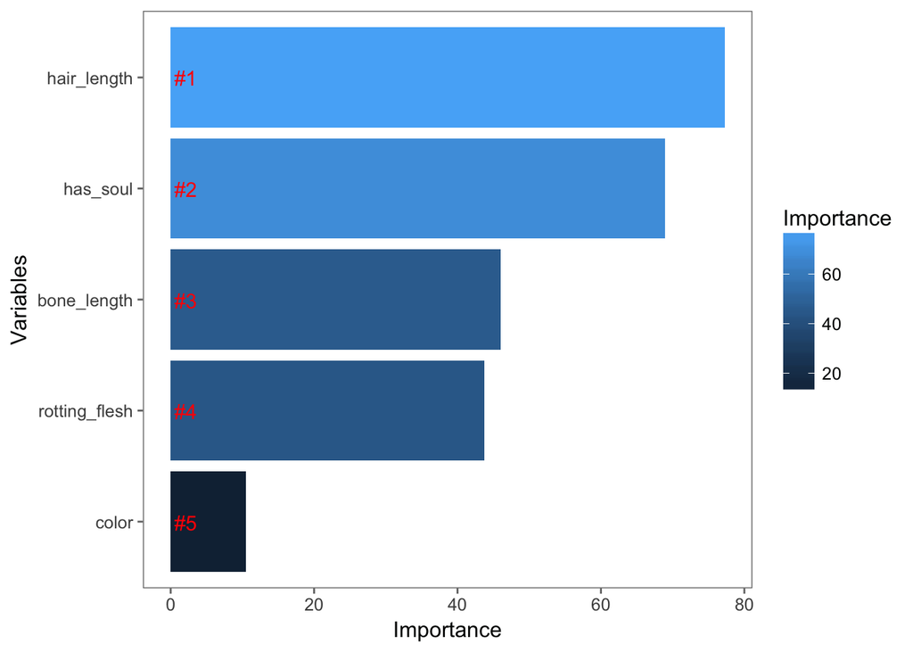

```r
set.seed(754)

# Transformar o color em factor
train$color <- factor(train$color)

#
rf_model <- randomForest(factor(type) ~ bone_length + rotting_flesh + hair_length + has_soul + color, data = train)

# Obter a importancia de cada var
importance <- importance(rf_model)
varImportance <- data.frame(Variables = row.names(importance), Importance = round(importance[,'MeanDecreaseGini'],2))

# Criar um rank
rankImportance <- varImportance %>% mutate(Rank = paste0('#', dense_rank(desc(Importance))))


ggplot(rankImportance, aes(x = reorder(Variables, Importance),
    y = Importance, fill = Importance)) +
  geom_bar(stat='identity') +
  geom_text(aes(x = Variables, y = 0.5, label = Rank),
    hjust=0, vjust=0.55, size = 4, colour = 'red') +
  labs(x = 'Variables') +
  coord_flip() +
  theme_few()
```

We can see that `hair_length` and `has_soul` are the two most important features. Let’s see in a scatter plot:

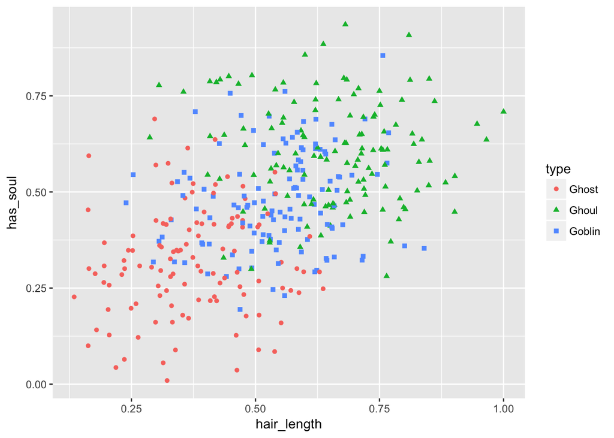

```r
ggplot(train, aes(x = hair_length, y = has_soul, shape = type, color = type)) + geom_point()
```

As we can see, there is a concentration of ghosts in the left bottom part, a concentration of goblins in the middle, and ghouls in the top right of the chart.

The first conclusion is that ghosts have less hair and soul, ghouls have more hair and soul, and goblins are in the middle.

There are 4 creatures that are close to each other, two ghosts, a ghoul and a goblin, with close hair size e soul. What the difference between them? Let’s find this 4 guys and see!

```r
creatures <- train[train$has_soul > 0.30 & train$has_soul < 0.375 & train$hair_length > 0.425 & train$hair_length < 0.475,]
creatures
```

```
##      id bone_length rotting_flesh hair_length  has_soul color   type
## 31   69   0.6729771     0.6204786   0.4357145 0.3287166 clear  Ghoul
## 106 233   0.5198274     0.5684410   0.4341712 0.3518510 clear  Ghost
## 121 286   0.2734580     0.4632386   0.4535155 0.3363903 white Goblin
## 298 715   0.5005233     0.3901658   0.4575028 0.3464743 clear  Ghost
```

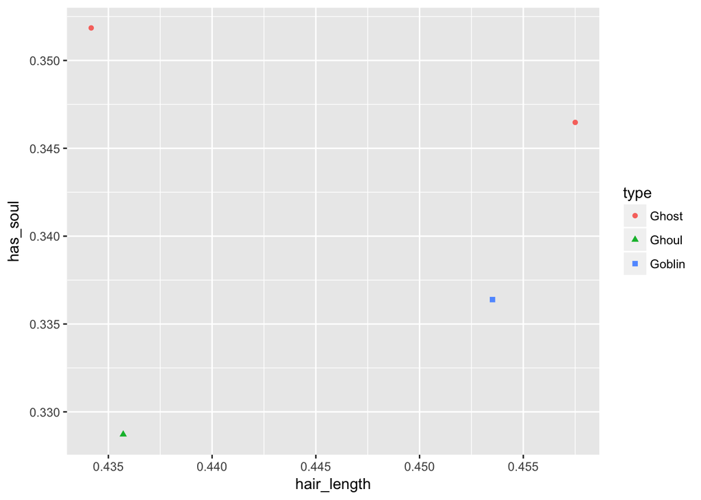

```r
ggplot(creatures, aes(x = hair_length, y = has_soul, shape = type, color = type)) + geom_point()
```

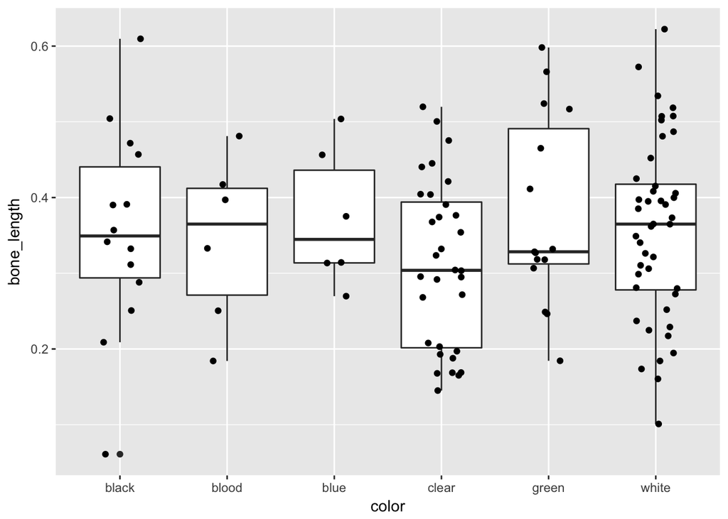

```r
# Bone length by color
ggplot(ghosts, aes(color, bone_length)) + geom_boxplot() + geom_jitter(width = 0.2)
```

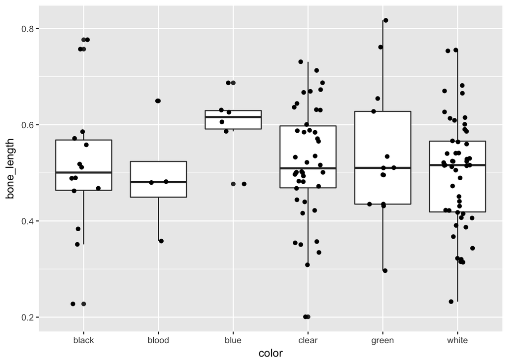

```r
ggplot(ghouls, aes(color, bone_length)) + geom_boxplot() + geom_jitter(width = 0.2)
```

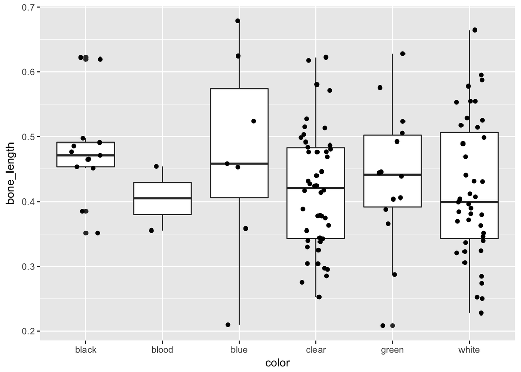

```r
ggplot(goblins, aes(color, bone_length)) + geom_boxplot() + geom_jitter(width = 0.2)
```

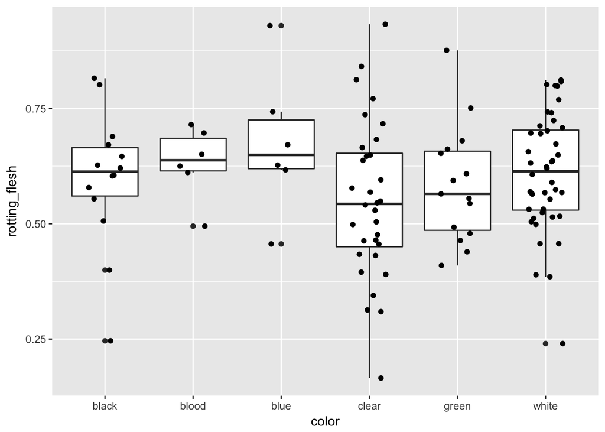

```r
# Rotting flesh by color
ggplot(ghosts, aes(color, rotting_flesh)) + geom_boxplot() + geom_jitter(width = 0.2)
```

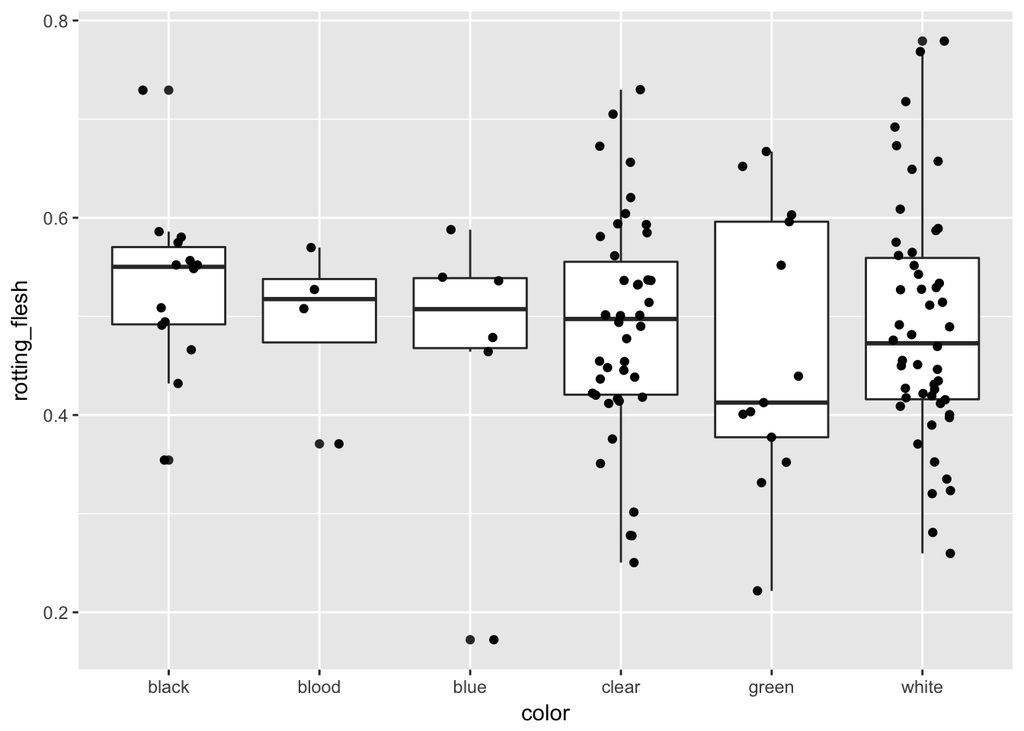

```r
ggplot(ghouls, aes(color, rotting_flesh)) + geom_boxplot() + geom_jitter(width = 0.2)
```

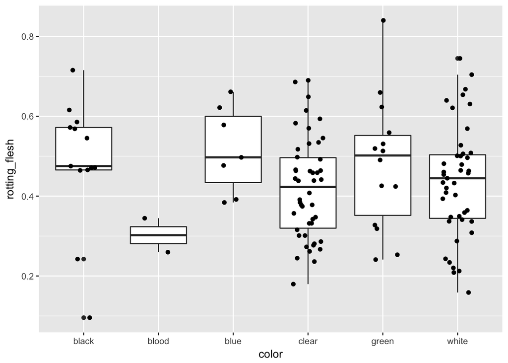

```r
ggplot(goblins, aes(color, rotting_flesh)) + geom_boxplot() + geom_jitter(width = 0.2)
```

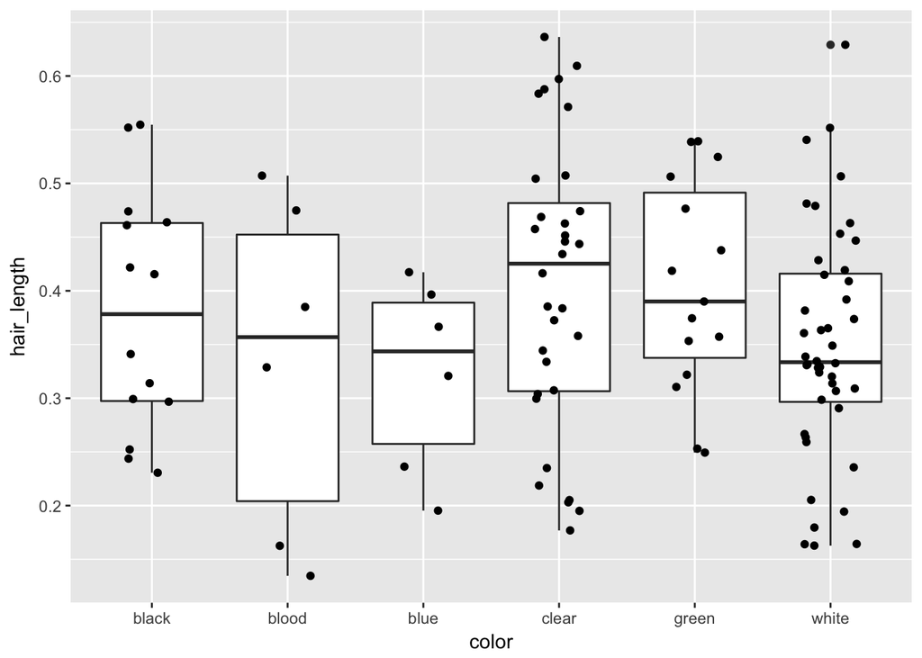

```r
# Hair length by color
ggplot(ghosts, aes(color, hair_length)) + geom_boxplot() + geom_jitter(width = 0.2)
```

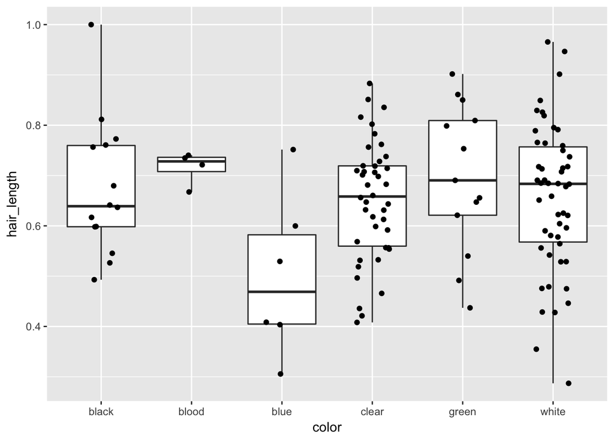

```r
ggplot(ghouls, aes(color, hair_length)) + geom_boxplot() + geom_jitter(width = 0.2)
```

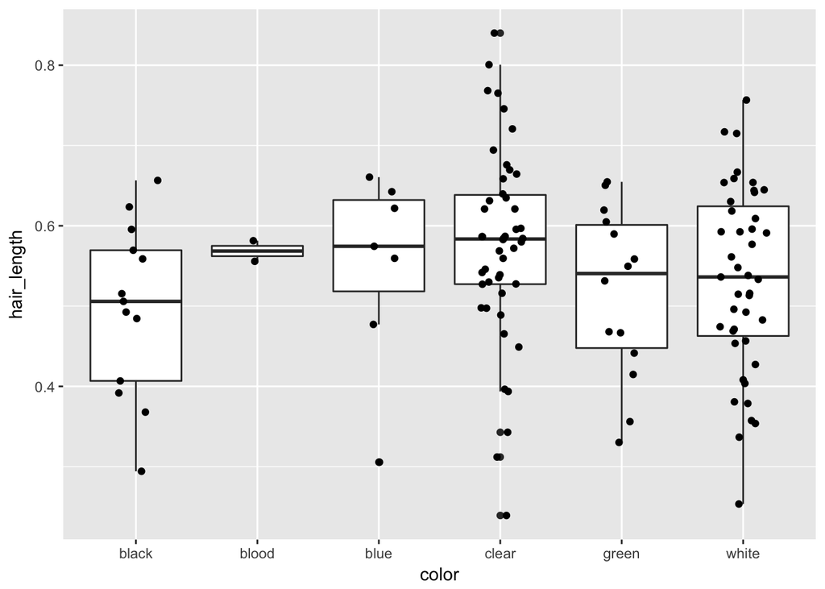

```r
ggplot(goblins, aes(color, hair_length)) + geom_boxplot() + geom_jitter(width = 0.2)
```

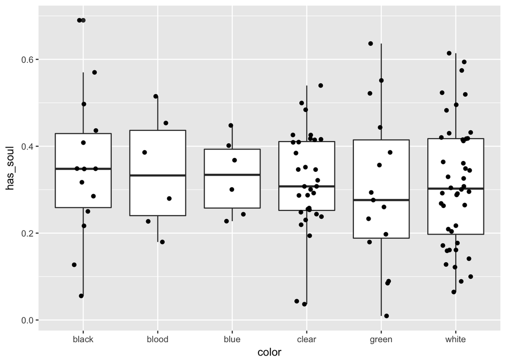

```r
# Soul by color
ggplot(ghosts, aes(color, has_soul)) + geom_boxplot() + geom_jitter(width = 0.2)
```

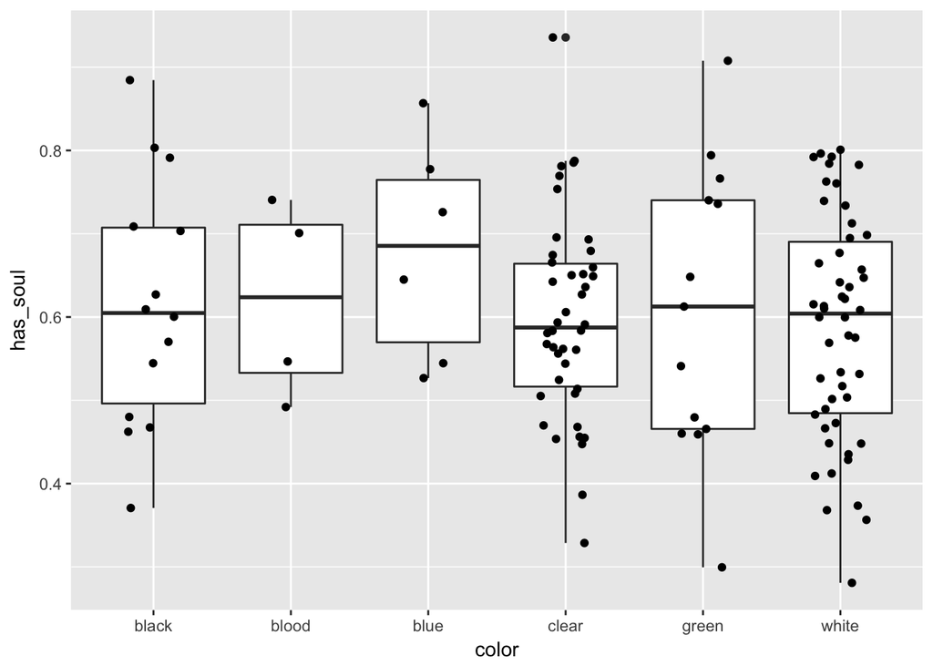

```r
ggplot(ghouls, aes(color, has_soul)) + geom_boxplot() + geom_jitter(width = 0.2)
```

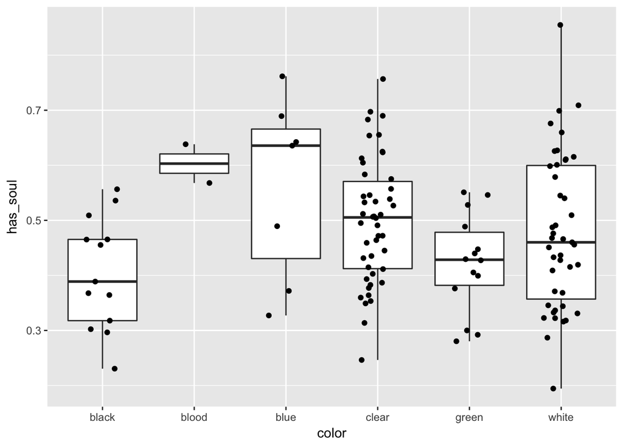

```r
ggplot(goblins, aes(color, has_soul)) + geom_boxplot() + geom_jitter(width = 0.2)
```